# Requirements Planning in a Worksheet and in Code

Manuel D. Rossetti, PhD P.E.

## Agenda

- The four sheets of `Chapter6Models.xlsx`, and why the periods run across
- The record computed twice, the explosion with its structure live, the lumpiness comparison, and the network
- The software: what it must do, and the nouns it is built from
- The join with the dynamic lot sizing code, and one interface for every rule
- Why a distribution network is built as a bill of material
- The chapter’s examples, run

## The Four Sheets

| Sheet | What it does | Which part of the chapter |
| --- | --- | --- |
| `Record` | the same requirements carried forward twice, without and with netting | the record, and the $\max$ |
| `Explosion` | the structure in three columns, then one record per item in low-level-code order | the explosion of all five items |
| `Lumpiness` | what each rule has the deck assembly receive, with its order count and variability coefficient | what lot sizing does to the level below |
| `DRP` | three regions and a center, every quantity per equal to one | the same calculation on a network |

**The periods run across the columns,** the reverse of the dynamic lot sizing workbook. That is not this book’s choice: a planner reads one item’s six rows at a time and compares them with each other, and the layout follows the field.

## `Record`: Computed Twice

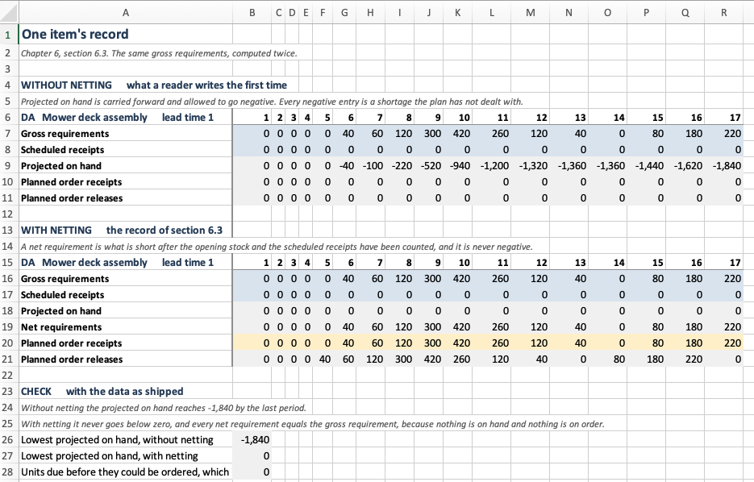

The upper block carries the balance forward **without netting**: it has no net requirement row at all, and its projected on hand runs to $-1{,}840$.

The lower block **nets**, and its projected on hand never leaves zero.

Notice that the two blocks share a gross requirement row to the unit. The only thing that differs between them is one formula, and putting them one above the other is the point of the sheet.

## `Explosion`: the Structure Is Live

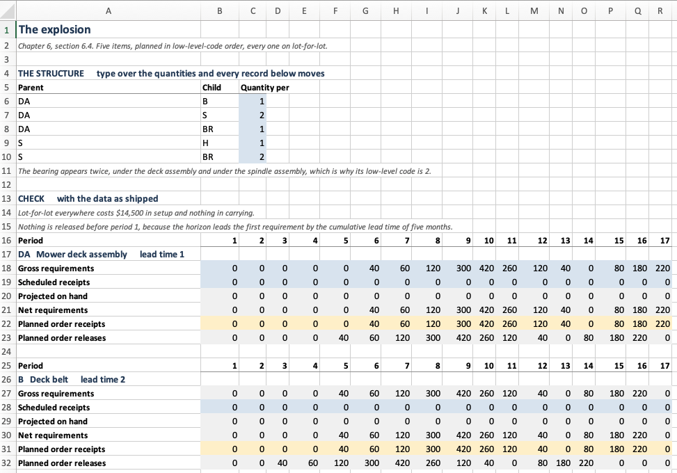

The structure sits in three columns at the top. The five blue cells in column C are the **quantities per**, and every component’s gross requirement formula reads them: the explosion equation written out, one term per parent.

Notice the deck belt’s gross requirement row against the deck assembly’s release row above it. They are the same numbers, because the quantity per is one.

Type a 3 over the 2 and every record below the spindle assembly moves.

## `Explosion`: the Bearing and the Totals

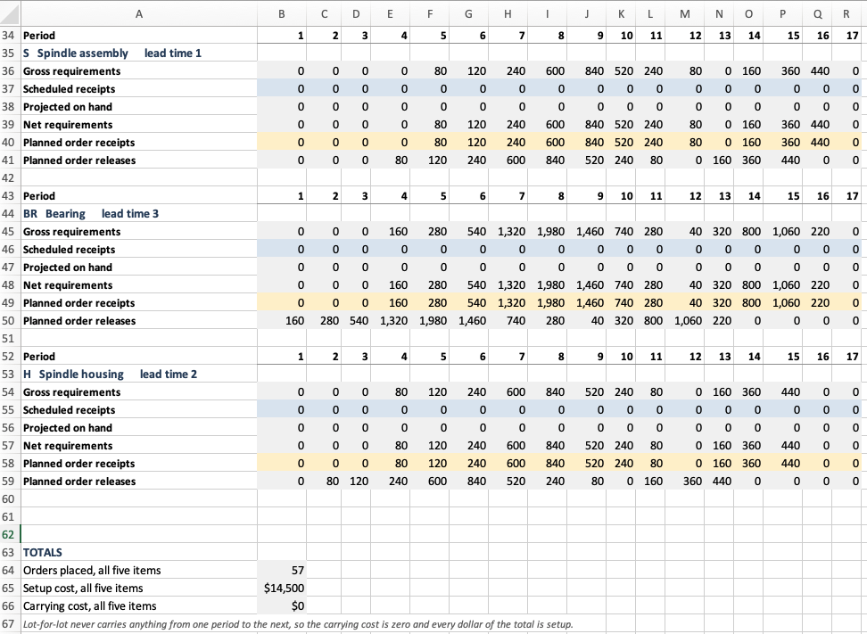

The spindle assembly, the bearing, the housing, and the totals.

The bearing’s gross requirements are the largest numbers on the sheet, reaching **1,980** in period 8. Five bearings per deck and two paths through the structure will do that.

The three cells at the foot make the first session’s cost computable: **57 orders, $14,500 of setup, and nothing carried.**

## `Lumpiness`

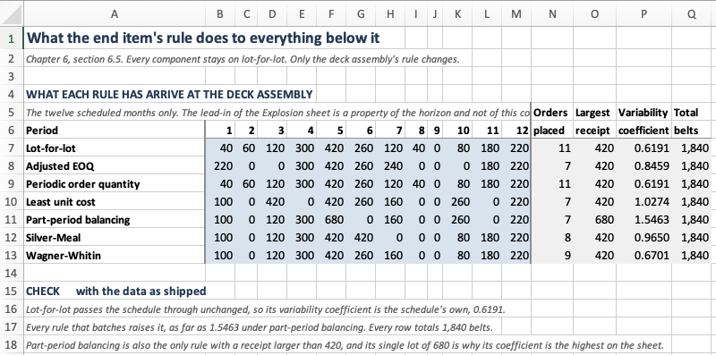

Each row is what one rule has the deck assembly receive over the twelve scheduled months. The variability coefficient is written as the mean of the squares less the square of the mean, over the square of the mean, because the more obvious `SUMPRODUCT((range - mean)^2)` is an array expression a reader cannot follow by clicking on it.

Notice the Largest receipt column: six of the seven rules never exceed 420, and part-period balancing’s single lot of **680** is why its coefficient is the highest on the sheet. The Total column reads 1,840 on every row, and is there to be checked.

## `DRP`: the Explosion Sheet on Its Side

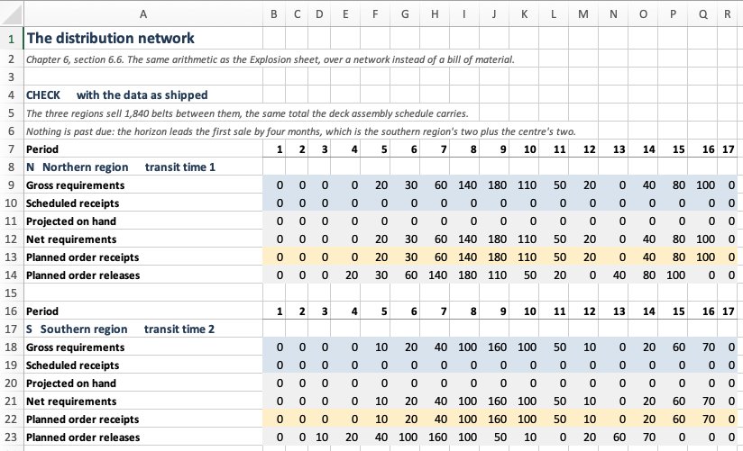

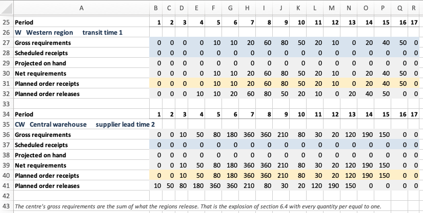

Each region is planned exactly as an end item is planned on the `Explosion` sheet; the only word that changes is the one naming the offset, a transit time for a lead time. The center’s gross requirement row is the three release rows added down the column, and nothing else.

Notice period 3, where the center needs ten belts: the southern region alone is asking, because its transit time is a month longer than the other two.

## What the Software Must Do

1. Hold a product structure, with quantities per, and assign low-level codes.
2. Hold what the planner knows about an item that is not its requirements.
3. Compute one item’s record: net, lot size, offset.
4. Explode a master production schedule through the structure, in the right order.
5. Do the same over a distribution network.
6. Report what a plan costs, by item and in total.

Requirement 5 is the one to watch. It looks like a second feature, and the design argues that it is not one.

## Finding the Nouns

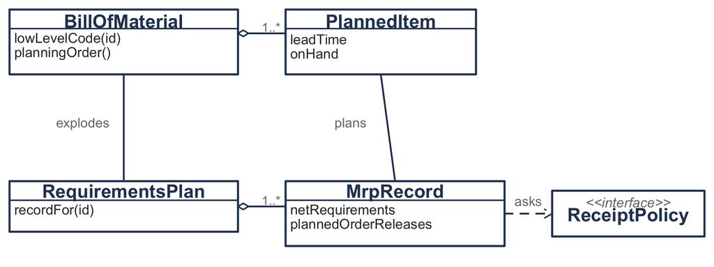

A **planned item** is what the item master holds: lead time, opening stock, what is on order, the costs, the rule. Not its requirements, which are computed.

A **bill of material** is the structure, and it owns the **low-level codes**: an item cannot answer what its own code is without seeing every path that reaches it.

An **MRP record** is one item’s six rows; a **requirements plan** is every item’s record, in the order computed; a **receipt policy** is how much to have arrive, given what must arrive.

*Level* is the instructive rejection. It reads like a class and the chapter uses the word constantly, but a level has no behavior: it is an integer attached to an item, and the only thing anyone does with it is sort by it.

## The Join with Dynamic Lot Sizing

The design turns on one sentence: **the net requirement stream is a requirements schedule** of the dynamic lot sizing chapter. Once that is said, no lot sizing rule needs an MRP version.

```kotlin
fun scheduleFor(netRequirements: List<Double>): RequirementsSchedule =
    RequirementsSchedule.constantCosts(label = label, requirements = netRequirements,
        orderCost = orderCost, unitCost = unitCost, carryingCharge = carryingCharge)
```

```kotlin
class PlanTheHorizon(private val rule: LotSizingRule) : ReceiptPolicy {
    override fun receiptsFor(netRequirements: List<Double>, item: PlannedItem): List<Double> {
        val first = netRequirements.indexOfFirst { it > 0.0 }
        if (first < 0) return netRequirements.map { 0.0 }
        val plan = rule.plan(item.scheduleFor(netRequirements.drop(first)))
        return netRequirements.indices.map {
            if (it < first) 0.0 else plan.orderIn(it - first + 1)
        }
    }
}
```

Notice the `drop`. It is part of the contract, not a convenience: a rule handed a stream that opens with empty periods places a receipt in the first of them and carries it. The empty periods are the horizon’s lead-in, not part of the problem.

## One Interface for Two Kinds of Rule

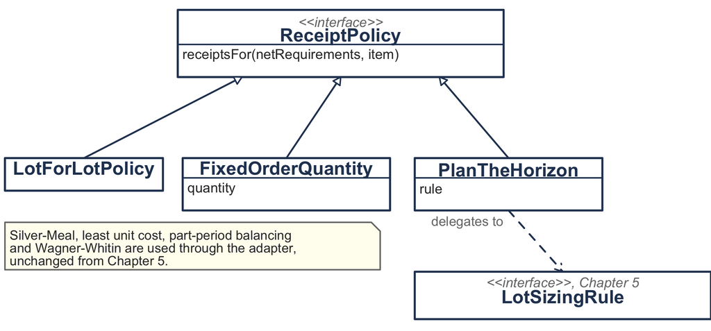

A fixed order quantity decides period by period and looks nowhere. Silver-Meal cannot decide anything until it has seen the whole horizon. They look as though they need two interfaces, and they do not:

```kotlin
fun interface ReceiptPolicy {
    fun receiptsFor(netRequirements: List<Double>,
                    item: PlannedItem): List<Double>
}
```

The net requirement stream is computed **before** any rule runs, so the whole of it is available to a rule that needs the whole of it.

The fixed order quantity is a rule the dynamic lot sizing chapter had to exclude, because it cannot finish the horizon empty. Inside a record it is admissible: what is left over is on hand at the start of the next planning cycle, which is what the projected on hand row is for.

## Two Readings of “Net Requirement”

The record computes in two sweeps, and this is the only place in the package where a name means two things.

**The first sweep** asks what would have to arrive in each period if nothing were carried beyond the opening stock and the scheduled receipts. That is the stream a policy is asked to cover, and it does not depend on the policy.

**The second sweep** works out what the policy’s receipts actually leave on hand, and recomputes the row the record prints. For example, a fixed order quantity that covers three periods at once makes the printed net requirement zero in the two periods after it, where the stream it was given had positive numbers.

```kotlin
val netRequirementsBeforeLotSizing: List<Double>   // what the policy is given
val netRequirements: List<Double>                  // what the record shows
```

Thus, two names. One property meaning whichever the caller needed would put the package into a quiet disagreement with every worked example in the literature.

## A Network Is a Bill of Material

The claim that distribution requirements planning is the same calculation is made **structural** by not writing a second class:

```kotlin
BillOfMaterial(
    locations,
    regions.map { BillOfMaterial.Usage(parent = it, child = "CW", quantity = 1.0) },
)
```

That is the whole of the network’s definition. `RequirementsPlan` assigns the low-level codes, which puts the regions at 0 and the center at 1, plans them in that order, and computes the center’s gross requirements as the sum over its parents.

The temptation is a `DistributionNetwork` class with `regions` and `center` on it. It would duplicate the low-level coding, the planning order and the explosion, and the two could then disagree about a network that is also a structure: a warehouse supplying both dealers and an assembly plant.

## Planning One Component

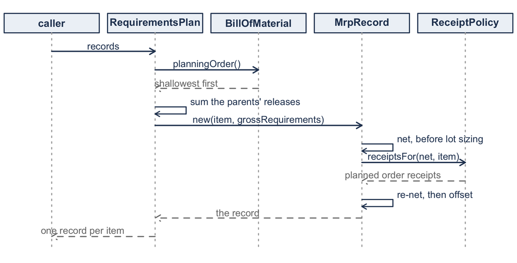

Notice that the record computes its net requirements **before** the policy is consulted, and re-nets after. Nothing in the trace would change if the graph were a network instead of a structure.

## The Structure, in Code

```kotlin
val bom = BillOfMaterial(
    listOf(
        PlannedItem("DA", "Mower deck assembly", leadTime = 1, policy = LotForLotPolicy,
            orderCost = 500.0, unitCost = 180.0, carryingCharge = 0.02),
        PlannedItem("B", "Deck belt", leadTime = 2, policy = LotForLotPolicy,
            orderCost = 300.0, unitCost = 50.0, carryingCharge = 0.02),
        PlannedItem("S", "Spindle assembly", leadTime = 1, policy = LotForLotPolicy,
            orderCost = 250.0, unitCost = 25.0, carryingCharge = 0.03),
        PlannedItem("H", "Spindle housing", leadTime = 2, policy = LotForLotPolicy,
            orderCost = 150.0, unitCost = 12.0, carryingCharge = 0.02),
        PlannedItem("BR", "Bearing", leadTime = 3, policy = LotForLotPolicy,
            orderCost = 100.0, unitCost = 4.0, carryingCharge = 0.02),
    ),
    listOf(
        BillOfMaterial.Usage("DA", "B", 1.0),  BillOfMaterial.Usage("DA", "S", 2.0),
        BillOfMaterial.Usage("DA", "BR", 1.0), BillOfMaterial.Usage("S", "H", 1.0),
        BillOfMaterial.Usage("S", "BR", 2.0),
    ),
)
println(bom.lowLevelCodes.toSortedMap())   // {B=1, BR=2, DA=0, H=2, S=1}
println(bom.planningOrder())               // [DA, B, S, BR, H]
```

Notice that no level was typed anywhere. `lowLevelCodes` is the low-level code table and `planningOrder` is the order the explosion plans in, both read off the usages.

## Running the Explosion

```kotlin
val schedule = List(5) { 0.0 } +
    listOf(40.0, 60.0, 120.0, 300.0, 420.0, 260.0, 120.0, 40.0, 0.0, 80.0, 180.0, 220.0)
val plan = RequirementsPlan(bom, mapOf("DA" to schedule))
val bearing = plan.recordFor("BR")
println(bearing.grossRequirements.map { it.toInt() })
println(bearing.plannedOrderReleases.map { it.toInt() })
println("%d orders, %.0f setup, %.0f carrying"
    .format(bearing.orderCount, bearing.setupCost, bearing.carryingCost))
println("%.0f past due".format(plan.pastDueReleases))
```

```
[0, 0, 0, 160, 280, 540, 1320, 1980, 1460, 740, 280, 40, 320, 800, 1060, 220, 0]
[160, 280, 540, 1320, 1980, 1460, 740, 280, 40, 320, 800, 1060, 220, 0, 0, 0, 0]
13 orders, 1300 setup, 0 carrying
0 past due
```

The five zeros in front of `schedule` are the five-month lead-in, and the schedule is a map because a structure may have more than one end item. The first output row is the bearing’s gross requirements from the hand explosion, and `pastDueReleases` checks the horizon without reading the record.

## Changing One Rule

Changing a rule means changing one item’s policy. Putting the deck assembly on Silver-Meal, with every component still on lot-for-lot, is one row of the comparison table:

```kotlin
PlannedItem("DA", "Mower deck assembly", leadTime = 1,
    policy = PlanTheHorizon(SilverMeal),
    orderCost = 500.0, unitCost = 180.0, carryingCharge = 0.02)
```

```kotlin
println("%.0f at the deck assembly, %.0f in total"
    .format(plan.recordFor("DA").relevantCost, plan.relevantCost))
// 4936 at the deck assembly, 11636 in total
```

That is against $14,500 with lot-for-lot everywhere. Notice that `relevantCost` is available on the record and on the plan, which is what lets the comparison separate what a rule saved at the deck assembly from what it cost below: $\$11{,}636 - \$4{,}936 = \$6{,}700$, the Silver-Meal row’s Cost below.

## The Network, in the Same Two Classes

```kotlin
val regions = listOf("N" to 1, "S" to 2, "W" to 1)
val network = BillOfMaterial(
    regions.map { (id, transit) ->
        PlannedItem(id, "$id region", leadTime = transit, policy = LotForLotPolicy,
            orderCost = 200.0, unitCost = 50.0, carryingCharge = 0.02)
    } + PlannedItem("CW", "Central warehouse", leadTime = 2, policy = LotForLotPolicy,
        orderCost = 400.0, unitCost = 50.0, carryingCharge = 0.02),
    regions.map { (id, _) -> BillOfMaterial.Usage(parent = id, child = "CW", quantity = 1.0) },
)
val drp = RequirementsPlan(network, demand.mapValues { List(4) { 0.0 } + it.value })
println(network.lowLevelCodes.toSortedMap())   // {CW=1, N=0, S=0, W=0}
println(network.planningOrder())               // [N, S, W, CW]
println(drp.recordFor("CW").grossRequirements.map { it.toInt() })
// [0, 0, 10, 50, 80, 180, 360, 360, 210, 80, 30, 20, 120, 190, 150, 0]
```

The last row is the center’s roll-up. Notice the lead-in is four here and five above, because the network is a shallower graph, and notice what is absent: no class is told that the graph is a network. The only thing that says so is the word `region` in a label.

## What We Did Today

**The workbook’s periods run across,** because a planner reads one item’s six rows at a time; the `Record` sheet differs from itself in one formula.

**The `Explosion` sheet’s structure is live:** the quantities per are the cells every gross requirement formula reads.

**The net requirement stream is a requirements schedule,** so every dynamic lot sizing rule runs inside a record through one adapter, `PlanTheHorizon`.

**One interface serves every rule,** because netting happens before any rule runs; the record keeps two named readings of net requirement.

**A distribution network is a bill of material** with every quantity per equal to one, and the code proves it by having no second class.

## For Next Time

**Read before next session:** *One Order, One Chance* and *Working the Decision by Hand*, in the single-period chapter.

Today’s material was *Building These Models in a Worksheet* and *Designing the Software*.

Next session begins the second half of the course:

- Demand is a random variable, and there is exactly one ordering decision
- The cost of one too many against the cost of one too few
- The decision worked by hand first, from a table of probabilities

Everything so far has assumed demand is known. From here it is not, and the first model that admits it is also the simplest one in the book.

⌂ Index